# employee_churn_udacity

##### EducationField, JobRole Vs Attrition

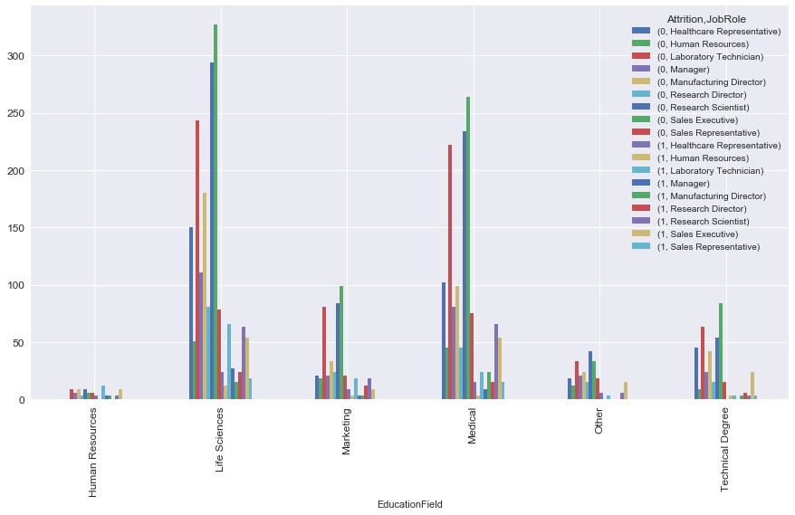

```python
import matplotlib.pyplot as plt
import seaborn as sns
# use Seaborn styles
sns.set()
pd.pivot_table(master_data, index= 'EducationField', columns= ['Attrition','JobRole'], values= "EmployeeID",aggfunc='count').plot(kind= 'bar',figsize=(15,8),fontsize=12)
```

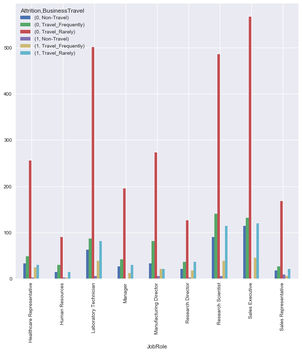

```python
import matplotlib.pyplot as plt
import seaborn as sns
# use Seaborn styles
sns.set()
pd.pivot_table(master_data, index=['JobRole'], columns= ['Attrition','BusinessTravel'], values= "EmployeeID",aggfunc='count').plot(kind= 'bar',figsize=(10,10))
```

##### Correlation Plot

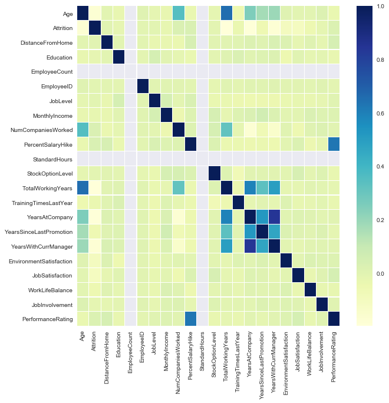

```python
corrmat = master_data.corr(method='spearman')
f, ax = plt.subplots(figsize=(10, 10))
sns.heatmap(corrmat, ax=ax, cmap="YlGnBu", linewidths=0.1)
```

###### Employees that have already worked at several companies previously show higher proportion of leavers when compared to active members.

### Data Preprocessing

##### Dropping Unwanted Columns

```python
#Since these columns has only one level dropping the columns
master_data1=master_data.drop(['Over18','EmployeeCount', 'StandardHours','EmployeeID'],axis=1)
```

##### Imputing the missing values with mean of the columns

```python
from sklearn.preprocessing import Imputer
imp = Imputer(missing_values='NaN', strategy='mean', axis=0)
mis_cols=['NumCompaniesWorked','EnvironmentSatisfaction','JobSatisfaction','WorkLifeBalance','TotalWorkingYears']
for col in mis_cols:
    master_data1[col] =imp.fit_transform(master_data1[[col]])
    master_data1[col]=round( master_data1[col])
```

##### Standardising the columns whose values are not on the same scale

```python
cols=['Age','DistanceFromHome','MonthlyIncome','PercentSalaryHike','TotalWorkingYears','YearsAtCompany','YearsWithCurrManager']
```

```python
from sklearn.preprocessing import StandardScaler
scaler = StandardScaler()
for col in cols:
    master_data1[col]=scaler.fit_transform(master_data1[[col]])
```

##### One hot encoding the categorical Values

```python
master_data_dummies=pd.get_dummies(master_data1,drop_first=True)
```

##### Segregating the independent features and the target feature(Attrition)

```python
features=master_data_dummies.drop("Attrition",axis=1)
```

```python
target=master_data_dummies["Attrition"]
```

##### Splitting the data into train and test samples (70:30)ratio

```python
X_train, X_test, y_train, y_test = train_test_split(features,
                                                    target,
                                                    test_size=0.30,
                                                    random_state=70,
                                                    stratify=target)
print("Number rows X_train: ", X_train.shape)
print("Number rows y_train: ", y_train.shape)
print("Number rows X_test : ", X_test.shape)
print("Number rows y_test : ", y_test.shape)
```

```
Number rows X_train:  (3087, 38)
Number rows y_train:  (3087,)
Number rows X_test :  (1323, 38)
Number rows y_test :  (1323,)
```

### Model Building

##### Function to display the Model Evaluation metrics

```python
# Function to disply model metrics
def model_metrics(target,pred):
        precision= metrics.precision_score(target,pred)
        recall= metrics.recall_score(target,pred)
        f1_score = metrics.f1_score(target,pred)
        fbeta_score = metrics.fbeta_score(target,pred, average='binary', beta=0.5)
        print ("Accuracy  : %.4g" % metrics.accuracy_score(target,pred))
        print('Precision :',round(precision,3))
        print('Recall : ',round(recall,3))
        print('F1 Score:',round(f1_score,3))
```

##### Training with different Algorithms

```python
models = []
models.append(('Logistic Regression', LogisticRegression(solver='liblinear', random_state=1,
                                                         class_weight='balanced')))
models.append(('XGBOOST', XGBClassifier(
    n_estimators=100, random_state=1)))
models.append(('Random Forest',RandomForestClassifier(bootstrap=True, class_weight='balanced',criterion='gini', max_depth=10,min_samples_leaf=4,
               min_samples_split=20, n_estimators=20)))
models.append(('SVM', SVC(gamma='auto', random_state=1,probability=True)))
models.append(('KNN', KNeighborsClassifier()))
models.append(('Gaussian NB', GaussianNB()))
```

##### Visualising the metrics of different Algorithms

```python
col_names = ['Algorithm', 'Accuracy','Precison','Recall','f1-score','AUC-ROC']
results_final = pd.DataFrame(columns=col_names)
i = 0
for name, model in models:
    model.fit(X_train, y_train)
    probs = model.predict_proba(X_test)[:, 1]
    roc_auc = roc_auc_score(y_test, probs)
    pred=model.predict(X_test)

    accuracy=metrics.accuracy_score(y_test,pred)
    precision= metrics.precision_score(y_test,pred)
    recall= metrics.recall_score(y_test,pred)
    f1_score = metrics.f1_score(y_test,pred)

    results_final.loc[i]=[name,accuracy,precision,recall,f1_score,roc_auc]
    i += 1
results_final.sort_values(by=['AUC-ROC'], ascending=False)
```

|  | Algorithm | Accuracy | Precison | Recall | f1-score | AUC-ROC |
| --- | --- | --- | --- | --- | --- | --- |
| 2 | Random Forest | 0.920635 | 0.723140 | 0.821596 | 0.769231 | 0.957531 |
| 3 | SVM | 0.871504 | 0.877193 | 0.234742 | 0.370370 | 0.902698 |
| 1 | XGBOOST | 0.871504 | 0.772152 | 0.286385 | 0.417808 | 0.892116 |
| 4 | KNN | 0.822373 | 0.423611 | 0.286385 | 0.341737 | 0.869748 |
| 0 | Logistic Regression | 0.687075 | 0.300199 | 0.708920 | 0.421788 | 0.772487 |
| 5 | Gaussian NB | 0.770219 | 0.343643 | 0.469484 | 0.396825 | 0.694205 |

#### Hyperparameter tuning using Gridsearch

```python
clf_rf=RandomForestClassifier( class_weight='balanced',random_state=1)
parameters = {'n_estimators': [5,10,15,20],
              'criterion':['gini','entropy'],
              'min_samples_split':[10,20,30],
              'min_samples_leaf': [10,15,20],
              'max_depth': [5,10,15]}

grid_search = GridSearchCV(clf_rf,
                        iid=True,
                        return_train_score=True,
                        param_grid=parameters,
                        scoring='roc_auc',
                        cv=10)

grid_fit = grid_search.fit(X_train, y_train)
clf_rf_best = grid_fit.best_estimator_
print("best params: " + str(grid_search.best_params_))
print('best score:', grid_search.best_score_)
```

```
best params: {'criterion': 'entropy', 'max_depth': 15, 'min_samples_leaf': 10, 'min_samples_split': 10, 'n_estimators': 20}
best score: 0.9422177187350613
```

##### Final Model and feature importance

```python
pred_best=clf_rf_best.predict(X_test)
```

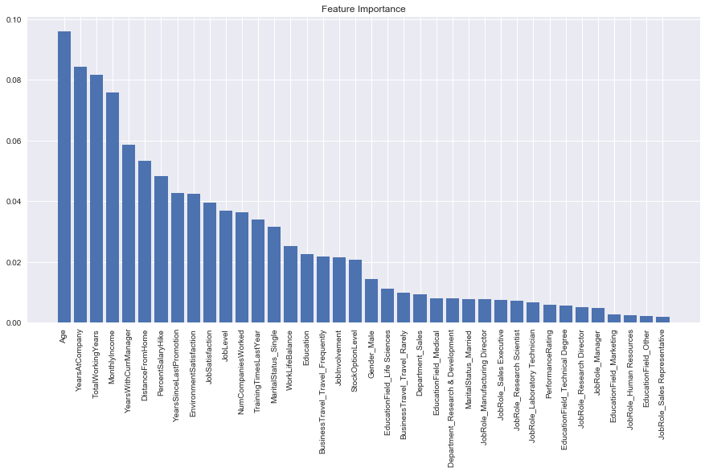

```python
importances = clf_rf_best.feature_importances_
indices = np.argsort(importances)[::-1] # Sort feature importances in descending order
names = [X_train.columns[i] for i in indices] # Rearrange feature names so they match the sorted feature importances
plt.figure(figsize=(15, 7)) # Create plot
plt.title("Feature Importance") # Create plot title
plt.bar(range(X_train.shape[1]), importances[indices]) # Add bars
plt.xticks(range(X_train.shape[1]), names, rotation=90) # Add feature names as x-axis labels
plt.show() # Show plot
```

```python
importances = clf_rf_best.feature_importances_
df_param_coeff = pd.DataFrame(columns=['Feature', 'Coefficient'])
for i in range(38):

    feat = X_train.columns[i]
    coeff = importances[i]
    df_param_coeff.loc[i] = (feat, coeff)
df_param_coeff.sort_values(by='Coefficient', ascending=False, inplace=True)
df_param_coeff = df_param_coeff.reset_index(drop=True)
df_param_coeff.head(10)
```

|  | Feature | Coefficient |
| --- | --- | --- |
| 0 | Age | 0.096056 |
| 1 | YearsAtCompany | 0.084220 |
| 2 | TotalWorkingYears | 0.081539 |
| 3 | MonthlyIncome | 0.075812 |
| 4 | YearsWithCurrManager | 0.058501 |
| 5 | DistanceFromHome | 0.053185 |
| 6 | PercentSalaryHike | 0.048203 |
| 7 | YearsSinceLastPromotion | 0.042726 |
| 8 | EnvironmentSatisfaction | 0.042455 |
| 9 | JobSatisfaction | 0.039415 |

##### Model Evaluation Metrcis

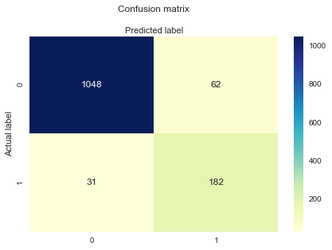

```
Accuracy  : 0.9297
Precision : 0.746
Recall :  0.854
F1 Score: 0.796
```

```python
cnf_matrix = metrics.confusion_matrix(y_test,pred_best)
class_names=[0,1] # name  of classes
fig, ax = plt.subplots()
tick_marks = np.arange(len(class_names))
plt.xticks(tick_marks, class_names)
plt.yticks(tick_marks, class_names)
# create heatmap
sns.heatmap(pd.DataFrame(cnf_matrix), annot=True, cmap="YlGnBu" ,fmt='g')
ax.xaxis.set_label_position("top")
plt.tight_layout()
plt.title('Confusion matrix', y=1.1)
plt.ylabel('Actual label')
plt.xlabel('Predicted label')
plt.show()
model_metrics(y_test,pred_best)
```

###### Model Evaluation using -K fold CrossValidation

```python
kfold = model_selection.KFold(n_splits=10, random_state=1)
scoring = 'roc_auc'
results = model_selection.cross_val_score(
    clf_rf_best, X_train, y_train, cv=kfold, scoring=scoring)
print("Mean AUC score: %.2f " % (results.mean()))
```

```
Mean AUC score: 0.94
```

##### Model Evaluation using -ROC Curve

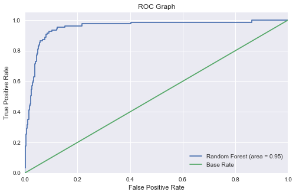

```python
from sklearn.metrics import roc_curve
rf_fpr, rf_tpr, rf_thresholds = roc_curve(y_test, clf_rf_best.predict_proba(X_test)[:,1])
plt.figure(figsize=(8, 5))
# Plot Random Forest ROC
plt.plot(rf_fpr, rf_tpr, label='Random Forest (area = %0.2f)' % roc_auc_score(y_test, clf_rf_best.predict_proba(X_test)[:,1]))
# Plot Base Rate ROC
plt.plot([0,1], [0,1],label='Base Rate')
plt.xlim([0.0, 1.0])
plt.ylim([0.0, 1.05])
plt.xlabel('False Positive Rate')
plt.ylabel('True Positive Rate')
plt.title('ROC Graph')
plt.legend(loc="lower right")
plt.show()
```

### Conclusions

##### As the company generates more data on its employees algorithm can be re-trained using the additional data and theoritically generate more accurate predictions to identify high-risk employees

##### Employees can be assigning a "Risk Category" based on the predicted probaility label such that:

##### Low-risk for employees with label < 0.6

##### Medium-risk for employees with label between 0.6 and 0.8

##### High-risk for employees with label > 0.8